## The goal of collecting this dataset

our goal is to Identify whether the chances of of a heart attack occurrence is high or low for the patient

#classification and clustering goal

Classification: We will classify target people into different groups based on appearance of muilty symptoms of Heart attack disease .This will allow us to predict the people who target to have heart attack based on certain factors .(classification done by Raghad and Taif)

Clustering: We will create a set of clusters for people who have similar symptoms. This will allow us to identify groups of people who are have the similar symptoms and target to have heart attack .(Clustring done by Sara and Leena)

We believe that by using these data mining tasks, we can build a model that can accurately predict the people target to have heart attack.

#modification on the pre processing done by Raghad and Taif.

The dataset was sourced from the kaggle website in this URL: https://www.kaggle.com/datasets/pritsheta/heart-attack

## General information

1- Number of Attributes: 14 2- Number of Objects: 303 3- Type of Attributes:

[output not shown]

Class label: -target of Heart Attack accurrance -not target of Heart Attack accurrance

| view dataset: |
| --- |

```r
library(readxl)
dataset <- read_excel("Heart Attack Data Set.xlsx")
View(dataset)
```

| Summary of dataset: |
| --- |

```r
nrow(dataset)
```

```
## [1] 303
```

```r
ncol(dataset)
```

```
## [1] 14
```

```r
summary(dataset$age)
```

```
##    Min. 1st Qu.  Median    Mean 3rd Qu.    Max.
##   29.00   47.50   55.00   54.37   61.00   77.00
```

```r
summary(dataset$cp)
```

```
##    Min. 1st Qu.  Median    Mean 3rd Qu.    Max.
##   0.000   0.000   1.000   0.967   2.000   3.000
```

```r
summary(dataset$trestbps)
```

```
##    Min. 1st Qu.  Median    Mean 3rd Qu.    Max.
##    94.0   120.0   130.0   131.6   140.0   200.0
```

```r
summary(dataset$chol)
```

```
##    Min. 1st Qu.  Median    Mean 3rd Qu.    Max.
##   126.0   211.0   240.0   246.3   274.5   564.0
```

```r
summary(dataset$oldpeak)
```

```
##    Min. 1st Qu.  Median    Mean 3rd Qu.    Max.
##    0.00    0.00    0.80    1.04    1.60    6.20
```

```r
summary(dataset$thalach)
```

```
##    Min. 1st Qu.  Median    Mean 3rd Qu.    Max.
##    71.0   133.5   153.0   149.6   166.0   202.0
```

```r
summary(dataset$slope)
```

```
##    Min. 1st Qu.  Median    Mean 3rd Qu.    Max.
##   0.000   1.000   1.000   1.399   2.000   2.000
```

```r
summary(dataset$ca)
```

```
##    Min. 1st Qu.  Median    Mean 3rd Qu.    Max.
##  0.0000  0.0000  0.0000  0.7294  1.0000  4.0000
```

```r
summary(dataset$thal)
```

```
##    Min. 1st Qu.  Median    Mean 3rd Qu.    Max.
##   0.000   2.000   2.000   2.314   3.000   3.000
```

| Missing values and Null values |
| --- |

```r
is.na(dataset)
```

[output not shown]

[output cut: 593 more lines]

```r
sum(is.na(dataset))
```

```
## [1] 0
```

The output is false and 0 this indicates that the element in our dataset is not missing

Graphs

Boxplot

`## Warning: package 'ggplot2' is in use and will not be installed`

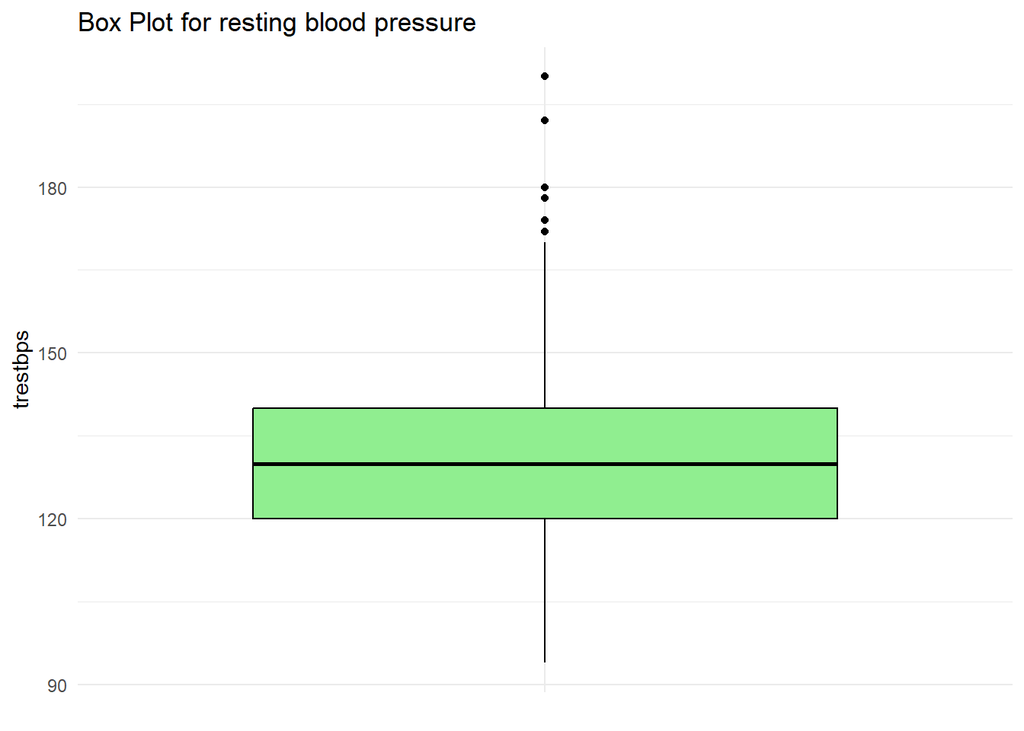

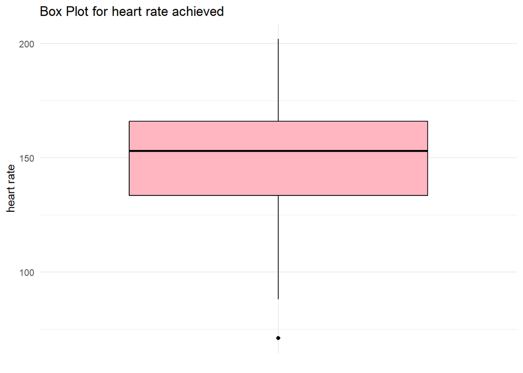

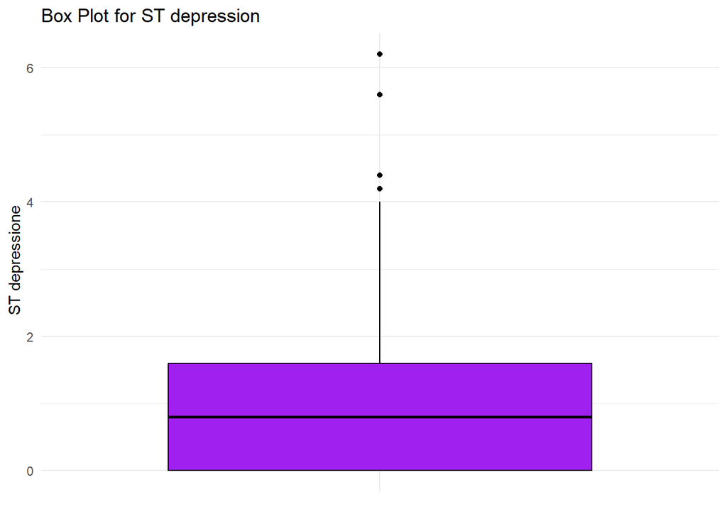

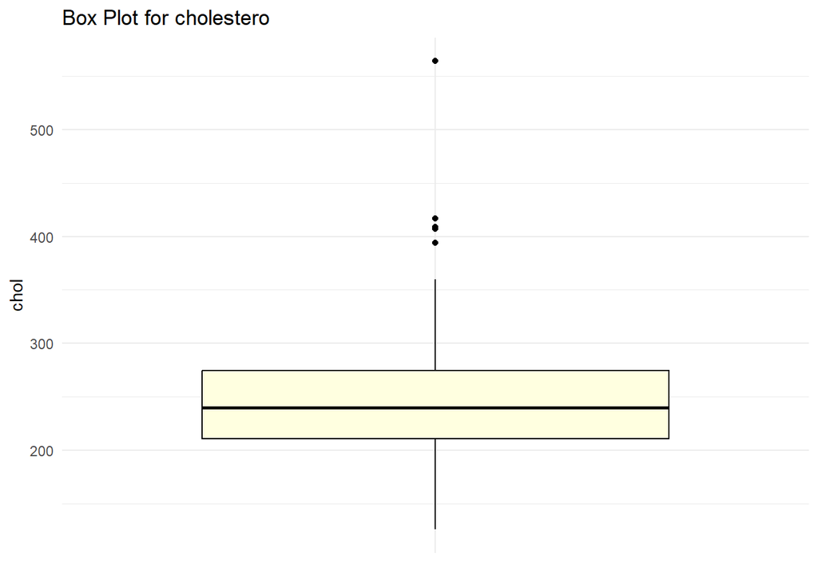

we can also detect summary of each attribute from the box plot , and we use box plot to detect the outlier.

Histogram

`r hist(dataset$chol)`

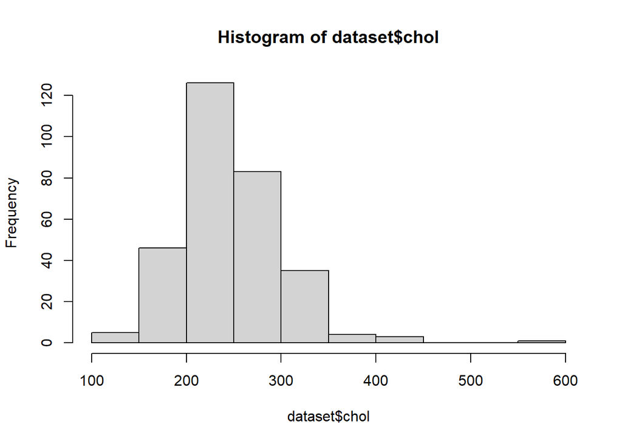

The graph represents the frequency of cholesterol in the data set. After observing the values, we concluded that most of the values fall in the range higher than the normal range, as the normal range falls between 125-200.

Scatter plot

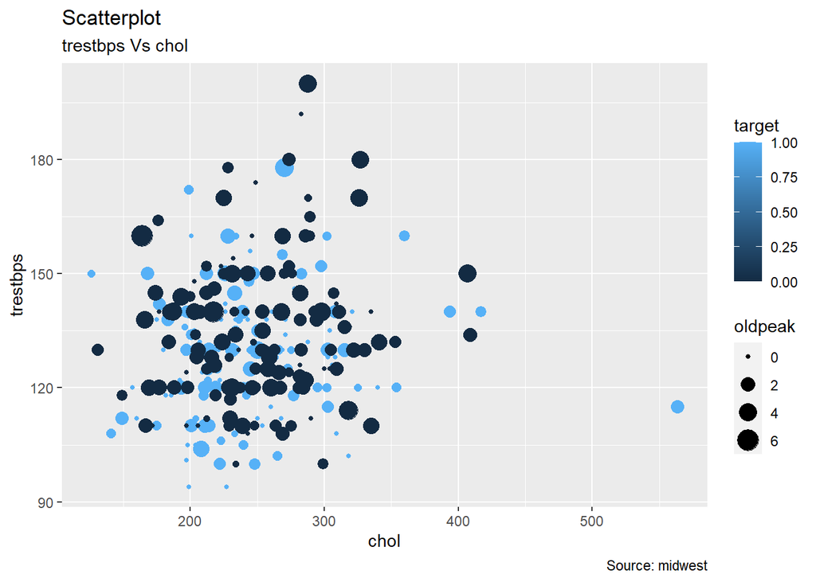

## Bar plot

There is no point in using bar plots because the frequency of one symptom (ex: high blood pressure alone ) is not enough to decide whether the patients are likely to have a heart attack or not

| outliers: |
| --- |

Detecting the outliers:

```r
  boxplot.stats (dataset$chol)$out
```

```
## [1] 417 564 394 407 409
```

```r
  boxplot.stats (dataset$trestbps)$out
```

```
## [1] 172 178 180 180 200 174 192 178 180
```

```r
  boxplot.stats (dataset$oldpeak)$out
```

```
## [1] 4.2 6.2 5.6 4.2 4.4
```

```r
  boxplot.stats (dataset$thalach)$out
```

```
## [1] 71
```

Removing the outliers:

```r
outliers <- boxplot (dataset$chol, plot=FALSE) $out
 dataset <- dataset [-which(dataset$chol %in% outliers),]
 boxplot.stats (dataset$chol) $out
```

```
## numeric(0)
```

The outlier in the attribute wasn’t a real Outlier and if we remove all the Outliers, our dataset affected and become small so we remove the Outlier from the attribute control that we noticed it is real Outlier.

[output not shown]

## we did not applly feature selection beacause the number of attribute is small and we will neeed them

##Correlation Analysis: We will find the correlation between each attributes and the class label (target). For the nominal data we will use chi-square and for the numeric data we will use correlation coefficient. This will help us to determine the most important and correlated attributes to the target.

```r
####Sex:

csex=chisq.test(dataset$sex , dataset$target)
print(csex)
```

```
##
##  Pearson's Chi-squared test with Yates' continuity correction
##
## data:  dataset$sex and dataset$target
## X-squared = 23.092, df = 1, p-value = 1.544e-06
```

```r
####Chest pain type (cp):

ccp=chisq.test(dataset$cp , dataset$target)
print(ccp)
```

```
##
##  Pearson's Chi-squared test
##
## data:  dataset$cp and dataset$target
## X-squared = 79.845, df = 3, p-value < 2.2e-16
```

```r
####Fasting blood sugar (fbs):

cfbs=chisq.test(dataset$fbs , dataset$target)
print(cfbs)
```

```
##
##  Pearson's Chi-squared test with Yates' continuity correction
##
## data:  dataset$fbs and dataset$target
## X-squared = 0.21655, df = 1, p-value = 0.6417
```

```r
####Resting electrocardiographic result (restecg):

crestecg=chisq.test(dataset$restecg , dataset$target)
print(crestecg)
```

```
##
##  Pearson's Chi-squared test
##
## data:  dataset$restecg and dataset$target
## X-squared = 10.351, df = 2, p-value = 0.005654
```

```r
####Exercise induced anginal (exang):

cexang=chisq.test(dataset$exang , dataset$target)
print(cexang)
```

```
##
##  Pearson's Chi-squared test with Yates' continuity correction
##
## data:  dataset$exang and dataset$target
## X-squared = 54.331, df = 1, p-value = 1.694e-13
```

```r
####The slope of the peak exercise ST segment (slope):

cslope=chisq.test(dataset$slope , dataset$target)
print(cslope)
```

```
##
##  Pearson's Chi-squared test
##
## data:  dataset$slope and dataset$target
## X-squared = 47.242, df = 2, p-value = 5.515e-11
```

```r
####Number of major vessels (ca):

cca=chisq.test(dataset$ca , dataset$target)
print(cca)
```

```
##
##  Pearson's Chi-squared test
##
## data:  dataset$ca and dataset$target
## X-squared = 72.093, df = 4, p-value = 8.202e-15
```

```r
####A blood disorder (thal):

cthal=chisq.test(dataset$thal , dataset$target)
print(cthal)
```

```
##
##  Pearson's Chi-squared test
##
## data:  dataset$thal and dataset$target
## X-squared = 83.556, df = 3, p-value < 2.2e-16
```

```r
####Age: The age attribute after discretization.

cage= chisq.test(dataset$age, dataset$target)
print(cage)
```

```
##
##  Pearson's Chi-squared test
##
## data:  dataset$age and dataset$target
## X-squared = 16.975, df = 3, p-value = 0.0007152
```

```r
####Resting blood pressure (trestbps)

ctrestbps=chisq.test(dataset$trestbps ,dataset$target)
print(ctrestbps)
```

```
##
##  Pearson's Chi-squared test
##
## data:  dataset$trestbps and dataset$target
## X-squared = 46.686, df = 48, p-value = 0.5267
```

[output not shown]

###Chi-square Results: We will sort the Chi-square values from the highest to the lowest:

| ###Correlation coefficient for numeric data: |
| --- |

```r
####Serum cholestoral (chol):

cchol=cor(dataset$chol ,dataset$target)
print(cchol)
```

```
## [1] -0.1167373
```

```r
####Maximum heart rate achieved (thalach):

cthalach=cor(dataset$thalach ,dataset$target)
print(cthalach)
```

```
## [1] 0.422917
```

```r
####ST depression indicated by exercise relative to rest (oldpeak):

coldpeak=cor(dataset$oldpeak ,dataset$target)
print(coldpeak)
```

```
## [1] -0.4287955
```

From the previous results we decided to delete the Fasting blood sugar (fbs) since it is independent from the class label (target) which means that fasting blood sugar (fbs) doesn’t affect our class label (target).

```r
dataset <- dataset[, -which(names(dataset) == "fbs")]
head(dataset)
```

```
## # A tibble: 6 × 13
##   age       sex    cp trestbps  chol restecg thalach exang oldpeak slope    ca
##   <fct>   <dbl> <dbl>    <dbl> <dbl>   <dbl>   <dbl> <dbl>   <dbl> <dbl> <dbl>
## 1 (59,69]     1 1        0.481 0.457       0   0.603     0  0.371    0       0
## 2 (29,39]     1 0.667    0.340 0.530       1   0.885     0  0.565    0       0
## 3 (39,49]     0 0.333    0.340 0.333       0   0.771     0  0.226    1       0
## 4 (49,59]     1 0.333    0.245 0.470       1   0.817     0  0.129    1       0
## 5 (49,59]     0 0        0.245 0.974       1   0.702     1  0.0968   1       0
## 6 (49,59]     1 0        0.434 0.282       1   0.588     0  0.0645   0.5     0
## # ℹ 2 more variables: thal <dbl>, target <dbl>
```

```r
ncol(dataset)
```

```
## [1] 13
```

```r
nrow(dataset)
```

```
## [1] 298
```

After printing a sample from our new data set we notice that the attribute decrease from 14 to 13 since we remove Fasting blood sugar (fbs) and the rows remain the same.

## print the final preprocessed dataset

```r
print(data)
```

[output not shown]

[output cut: 128 more lines]

[output not shown]

we apply chi-square and correlation coefficient to know the attribute that affect our class label in preprocessing ,then started work in classification. Classification: is a supervised learning technique where a model is trained on a labeled dataset, meaning the dataset has already been tagged or classified with the correct class labels. while we try to increase the accuracy, we try different way one of this way was add attribute and remove attribute and we noticed that the following attribute:slope , doesn’t affect accuracy adding them or removing them doesn’t change anything.

| Classification: |
| --- |

## data structure

```r
str(dataset)
```

```
## tibble [298 × 13] (S3: tbl_df/tbl/data.frame)
##  $ age     : Factor w/ 4 levels "(29,39]","(39,49]",..: 4 1 2 3 3 3 3 2 3 3 ...
##  $ sex     : num [1:298] 1 1 0 1 0 1 0 1 1 1 ...
##  $ cp      : num [1:298] 1 0.667 0.333 0.333 0 ...
##  $ trestbps: num [1:298] 0.481 0.34 0.34 0.245 0.245 ...
##  $ chol    : num [1:298] 0.457 0.53 0.333 0.47 0.974 ...
##  $ restecg : num [1:298] 0 1 0 1 1 1 0 1 1 1 ...
##  $ thalach : num [1:298] 0.603 0.885 0.771 0.817 0.702 ...
##  $ exang   : num [1:298] 0 0 0 0 1 0 0 0 0 0 ...
##  $ oldpeak : num [1:298] 0.371 0.5645 0.2258 0.129 0.0968 ...
##  $ slope   : num [1:298] 0 0 1 1 1 0.5 0.5 1 1 1 ...
##  $ ca      : num [1:298] 0 0 0 0 0 0 0 0 0 0 ...
##  $ thal    : num [1:298] 0.333 0.667 0.667 0.667 0.667 ...
##  $ target  : num [1:298] 1 1 1 1 1 1 1 1 1 1 ...
```

## split the data in training and test data (75/25)

```r
set.seed(123)
data_split <- initial_split(dataset, prop = 0.75)
train_data <- training(data_split)
test_data <- testing(data_split)
```